# SF3B1 iCLIP analysis

- Show All Code
- Hide All Code
- View Source

Differential binding

Author

Affiliation

Dr. Mirko Brueggemann

Buchman Institute for Molecular Life Sciences

Published

September 19, 2023

# 1 Analysis description

# 2 Load libraries

```r
library(rtracklayer)
library(GenomicRanges)
library(ggplot2)
library(AnnotationDbi)
library(dplyr)
library(reshape2)
library(UpSetR)
library(GenomicFeatures)
library(kableExtra)
library(knitr)
library(ggrepel)
library(gridExtra)
library(grid)
library(viridis)
library(BiocParallel)
library(DESeq2)
library(gplots)
library(ComplexHeatmap)
library(circlize)
library(GGally)
library(factoextra)
library(plotROC)
library(PRROC)
library(ggrastr)
library(ggbeeswarm)
library(ggpointdensity)
library(tidyr)
library(ggridges)
library(ggsci)
library(ggnewscale)
library(ggrastr)
library(Cairo)
library(ggforce)
library(patchwork)
library(dplyr)
library(tibble)
library(forcats)
library(stringr)
library(RColorBrewer)
library(ggpubr)
library(BindingSiteFinder)
library(Gviz)
library(ggpubr)
```

```r
source("../styles.R")
source("../helper.R")
```

# 3 Differential binding

Here we test whether SF3B1 changes its affinity to defined binding sites in the mutant condition (compared to the wt). This is done by using the DESeq2 NB model with the LRT (likelihood ratio test), to compare changes in binding sites to changes in the respective hosting gene. Essentially, we account for RNA abundance changes by approximating the transcript expression level by all iCLIP counts that do not end up in a binding site. We call this background counts. The DESeq2 model essentially uses these background counts to find binding sites that change independently from the underlying transcript level change, thus disentangling both signals.

```r
load("/Users/mirko/Projects/Annotations/human/gencode_36/filtered/gencode_v36_filtered.rda")
anno.db = loadDb("/Users/mirko/Projects/Annotations/human/gencode_36/filtered/gencode_v36_filtered.sqlite")
gns = genes(anno.db)
idx = match(gns$gene_id, anno$gene_id)
elementMetadata(gns) = cbind(elementMetadata(gns), elementMetadata(anno)[idx,])
names(gns) = sub("\\..*", "", names(gns))
meta = data.frame(gene_id = gns$gene_id, gene_name = gns$gene_name, gene_type = gns$gene_type)
mcols(gns) = meta
gns$geneID = names(gns)
```

```r
load("/Users/mirko/Projects/sf3b1/02_markdowns/01_transcriptome/01_bindingSites/data/bsTranscript.rda")
bindingSites = bsTranscript

# Load clip data
clipFilesWt = "/Users/mirko/Projects/sf3b1/01_data_subsamp/wt/cov/replicate"
clipFilesMut = "/Users/mirko/Projects/sf3b1/01_data_subsamp/mut/cov/replicate"
clipFiles = c(clipFilesWt, clipFilesMut)
clipFiles = list.files(clipFiles, pattern = ".bw$", full.names = TRUE)
clipFilesP = clipFiles[grep(clipFiles, pattern = "Plus")]
clipFilesM = clipFiles[grep(clipFiles, pattern = "Minus")]
# Organize clip data in dataframe
colData = data.frame(
    id = c(1:5),
    condition = factor(c("MUT", "MUT", "WT", "WT", "WT"), levels = c("MUT", "WT")),
    clPlus = clipFilesP,
    clMinus = clipFilesM)
# Make BindingSiteFinder object
bds = BSFDataSetFromBigWig(ranges = bindingSites, meta = colData)
```

```r
# compute the binding site and background coverage
bds.diff = calculateBsBackground(bds, anno.genes = gns)

# filter background
bds.diff = filterBsBackground(bds.diff)

# compute fold-changes
bds.diff = calculateBsFoldChange(bds.diff)
```

## 3.1 Gene-wise pre-filtering

**Filter minCount**

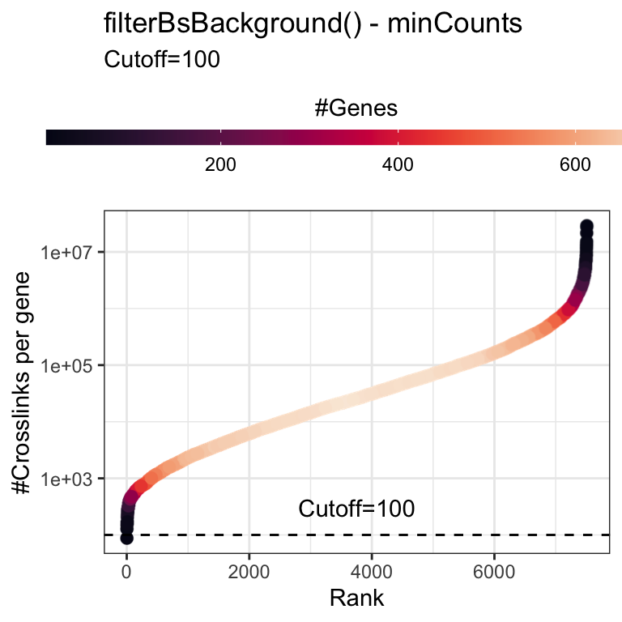

minCount filter

```r
plotBsBackgroundFilter(bds.diff, filter = "minCounts")
```

**Filter balanceBackground**

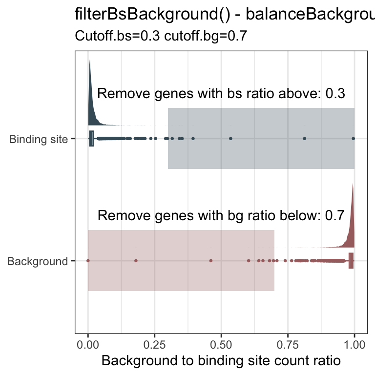

balanceBackground filter

```r
plotBsBackgroundFilter(bds.diff, filter = "balanceBackground")
```

**Filter balanceCondition**

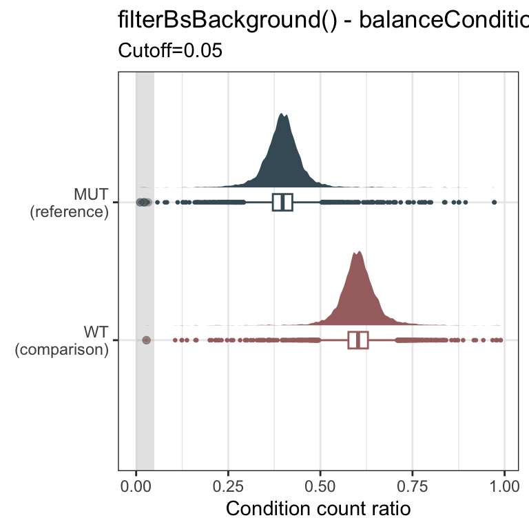

balanceCondition filter

```r
plotBsBackgroundFilter(bds.diff, filter = "balanceCondition")
```

## 3.2 Binding site level results

```r
df = getRanges(bds.diff) %>%
    as.data.frame() %>%
    mutate(bs.padj = replace_na(bs.padj, 1)) %>%
    mutate(sig = ifelse(bs.padj < 0.05, TRUE, FALSE)) %>%
    group_by(sig, region) %>%
    summarize(n = myFormat(n()))

kable(df, caption = "Result overview") %>%
  kable_styling("striped") %>%
  scroll_box(width = "100%")
```

Result overview

| sig | region | n |
| --- | --- | --- |
| FALSE | cds | 3,541 |
| FALSE | intron | 87,510 |
| FALSE | utr3 | 1,652 |
| FALSE | utr5 | 311 |
| TRUE | cds | 2 |
| TRUE | intron | 189 |
| TRUE | utr3 | 6 |
| TRUE | utr5 | 1 |

**MA plot**

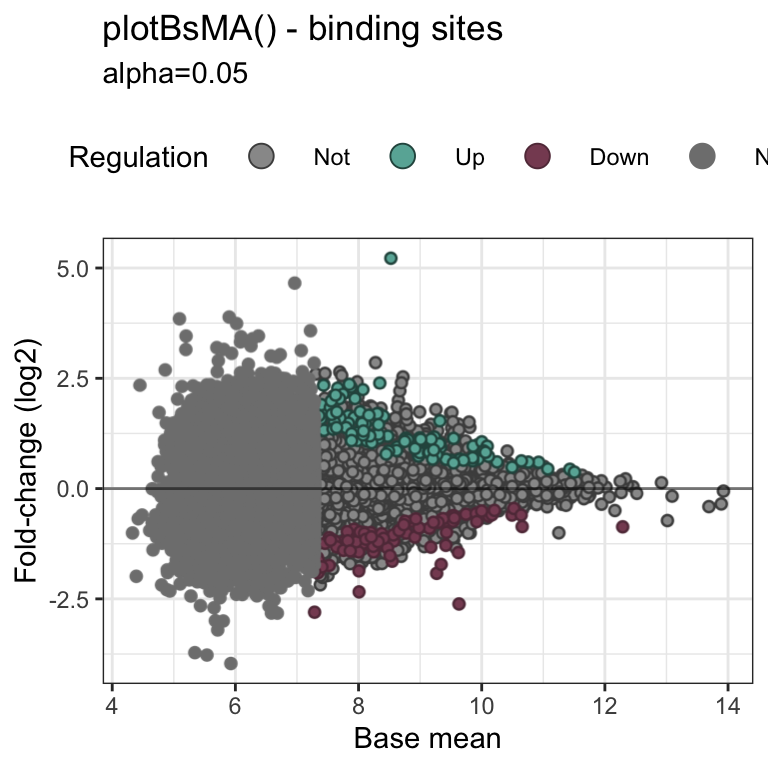

MA plot

```r
plotBsMA(bds.diff)
```

**Volcano plot**

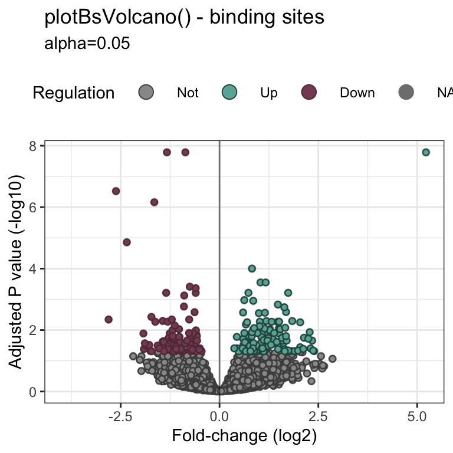

Volcano plot

```r
plotBsVolcano(bds.diff)
```

## 3.3 Gene level results

```r
df = getRanges(bds.diff) %>%
    as.data.frame() %>%
    mutate(bg.padj = replace_na(bg.padj, 1)) %>%
    mutate(sig = ifelse(bg.padj < 0.05, TRUE, FALSE)) %>%
    group_by(sig, region) %>%
    summarize(n = myFormat(n()))

kable(df, caption = "Result overview") %>%
  kable_styling("striped") %>%
  scroll_box(width = "100%")
```

Result overview

| sig | region | n |
| --- | --- | --- |
| FALSE | cds | 1,960 |
| FALSE | intron | 50,344 |
| FALSE | utr3 | 980 |
| FALSE | utr5 | 171 |
| TRUE | cds | 1,583 |
| TRUE | intron | 37,355 |
| TRUE | utr3 | 678 |
| TRUE | utr5 | 141 |

**MA plot**

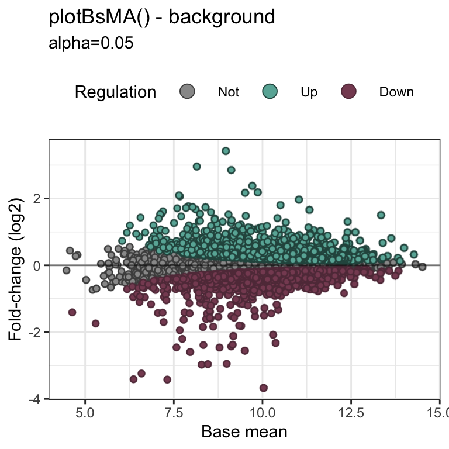

MA plot

```r
plotBsMA(bds.diff, what = "bg")
```

**Volcano plot**

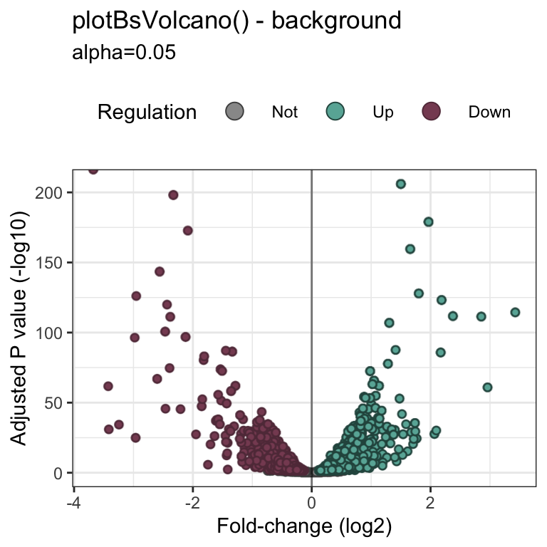

Volcano plot

```r
plotBsVolcano(bds.diff, what = "bg")
```

# 4 Integration with peak clustering

```r
# load peak classification from clustering
peakClass = rtracklayer::import.bed("../02_peakClassification/data/rngClassified.bed")
peakClass$group = sapply(strsplit(peakClass$name,"_"), `[`, 1)

# group peaks by classification
peakList = split(peakClass, peakClass$group)
# bsRes = searchRes$obj
bsRes = getRanges(bds.diff)

# get binding site LFCs, P-values, ect for binding sites in peak regions
olBs = subsetByOverlaps(bsRes,peakList$DoubleNarrow)
df1 = data.frame(BsID = olBs$bsID, GeneID = olBs$geneID, lfc = olBs$bs.log2FoldChange, padj = olBs$bs.padj, peakType = "DoubleNarrow")
olBs = subsetByOverlaps(bsRes,peakList$DoubleWide)
df2 = data.frame(BsID = olBs$bsID, GeneID = olBs$geneID, lfc = olBs$bs.log2FoldChange, padj = olBs$bs.padj, peakType = "DoubleWide")
olBs = subsetByOverlaps(bsRes,peakList$Rest)
df3 = data.frame(BsID = olBs$bsID, GeneID = olBs$geneID, lfc = olBs$bs.log2FoldChange, padj = olBs$bs.padj, peakType = "Rest")
olBs = subsetByOverlaps(bsRes,peakList$SinglePeak)
df4 = data.frame(BsID = olBs$bsID, GeneID = olBs$geneID, lfc = olBs$bs.log2FoldChange, padj = olBs$bs.padj, peakType = "SinglePeak")

# split double-wide peaks in left and right side
# -> based on midpoint
# -> left/ right switches with the strand
doublePeaks = peakList$DoubleWide
doublePeaks$doublePeakID = doublePeaks$name
doublePeaksP = doublePeaks[strand(doublePeaks) == "+"]
doublePeaksM = doublePeaks[strand(doublePeaks) == "-"]
doublePeaksP = as(slidingWindows(x = doublePeaksP, width = 41, step = 41), "GRangesList")
doublePeaksM = as(slidingWindows(x = doublePeaksM, width = 41, step = 41), "GRangesList")

doublePart1P = as(lapply(doublePeaksP, function(x){x[1]}),"GRangesList") %>% unlist()
doublePart2P = as(lapply(doublePeaksP, function(x){x[2]}),"GRangesList") %>% unlist()
doublePart1M = as(lapply(doublePeaksM, function(x){x[2]}),"GRangesList") %>% unlist()
doublePart2M = as(lapply(doublePeaksM, function(x){x[1]}),"GRangesList") %>% unlist()

doublePart1 = c(doublePart1P, doublePart1M)
mcols(doublePart1)$doublePeakID = doublePeaks$name
export(doublePart1, con = "./data/LeftPartFar.bed", format = "BED")
doublePart2 = c(doublePart2P, doublePart2M)
mcols(doublePart2)$doublePeakID = doublePeaks$name
export(doublePart2, con = "./data/RightPartClose.bed", format = "BED")

olBs = subsetByOverlaps(bsRes, doublePart1)
df5 = data.frame(BsID = olBs$bsID, GeneID = olBs$geneID, lfc = olBs$bs.log2FoldChange, padj = olBs$bs.padj, peakType = "DoubleWide-Left")
olBs = subsetByOverlaps(bsRes, doublePart2)
df6 = data.frame(BsID = olBs$bsID, GeneID = olBs$geneID, lfc = olBs$bs.log2FoldChange, padj = olBs$bs.padj, peakType = "DoubleWide-Right")
```

## 4.1 Grouping by peak classification

### 4.1.1 All

**Violin**

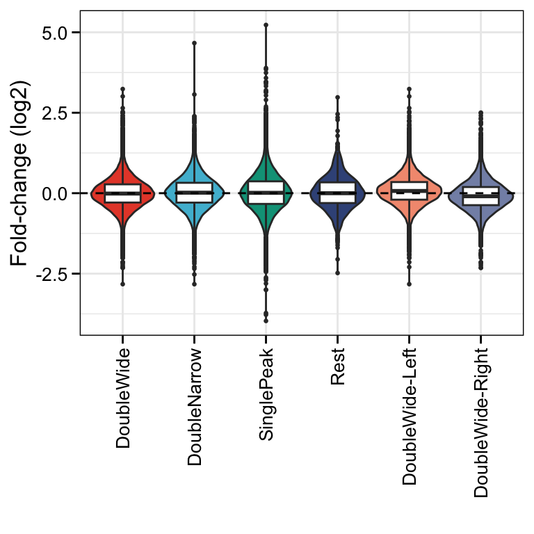

Violin chart

```r
df = rbind(df1,df2,df3,df4,df5,df6)
df$peakType = factor(df$peakType, levels = c("DoubleWide", "DoubleNarrow", "SinglePeak", "Rest", "DoubleWide-Left", "DoubleWide-Right"))

p1 = ggplot(df, aes(x = peakType, y = lfc, fill = peakType)) +
  geom_violin(adjust = 1, trim = T) +
  geom_boxplot(width = 0.5, fill = "white", outlier.size = 0.5) +
  theme_nice() +
  scale_fill_npg() +
  theme(legend.position = "none") +
  geom_hline(yintercept = 0, linetype = "dashed") +
  labs(x = "", y = "Fold-change (log2)") +
  theme(axis.text.x = element_text(angle = 90, vjust = 0.5, hjust=1))

p1
```

**Boxplot**

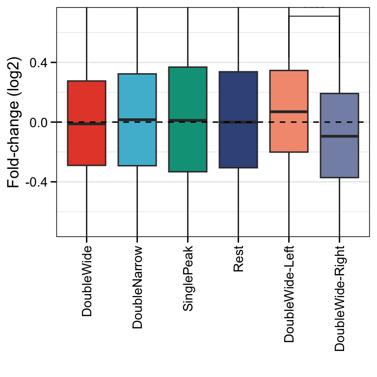

Boxplot

```r
p2 = ggplot(df, aes(x = peakType, y = lfc, fill = peakType)) +
  geom_boxplot(outlier.colour = NA) +
  theme_nice() +
  scale_fill_npg() +
  theme(legend.position = "none") +
  geom_hline(yintercept = 0, linetype = "dashed") +
  labs(x = "", y = "Fold-change (log2)") +
  theme(axis.text.x = element_text(angle = 90, vjust = 0.5, hjust=1)) +
  coord_cartesian(ylim = c(-0.7,0.7)) +
  stat_compare_means(comparisons = list(c("DoubleWide-Left", "DoubleWide-Right")), label = "p.signif", method = "wilcox.test", label.y = 0.25)

p2
```

**Barchart**

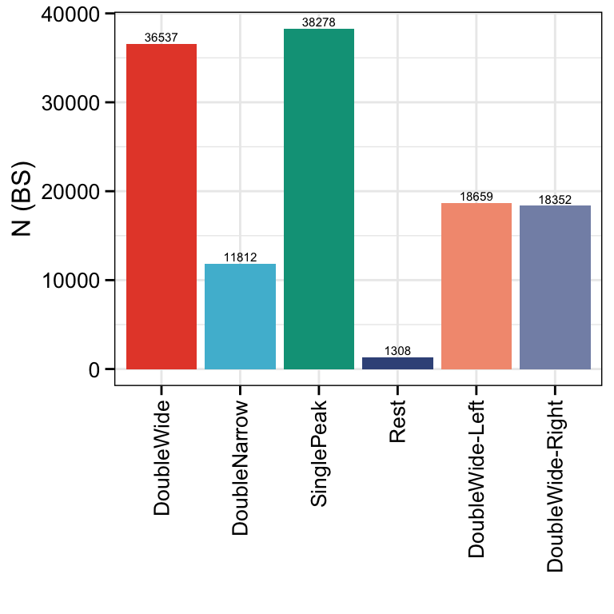

Barchart

```r
d = df %>% group_by(peakType) %>% summarise(n = n())
p3 = ggplot(d, aes(x = peakType, y = n, fill = peakType)) +
  geom_col() +
  scale_fill_npg() +
  geom_text(aes(label = n), vjust=-0.3, size = 2) +
  theme_nice() +
  theme(legend.position = "none") +
  labs(x = "", y = "N (BS)") +
  theme(axis.text.x = element_text(angle = 90, vjust = 0.5, hjust=1))

p3
```

### 4.1.2 Cleaned

**V1**

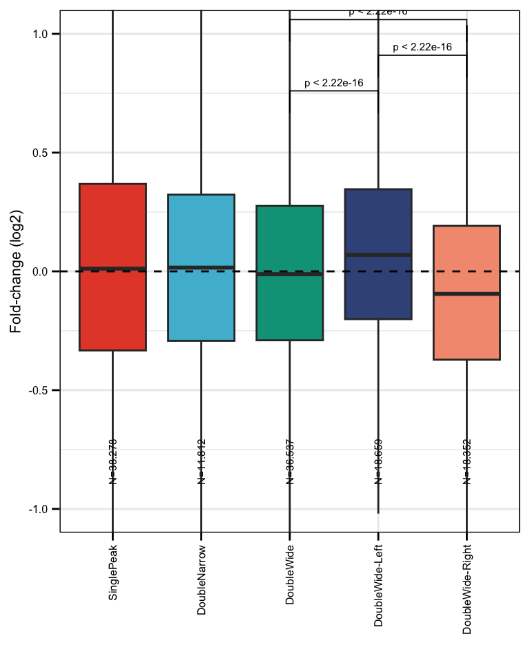

V1

```r
df = rbind(df1,df2,df3,df4,df5,df6) %>% filter(peakType != "Rest")
df$peakType = factor(df$peakType, levels = c("SinglePeak", "DoubleNarrow", "DoubleWide", "DoubleWide-Left", "DoubleWide-Right"))
compList = list(c("DoubleWide-Left", "DoubleWide-Right"), c("DoubleWide", "DoubleWide-Right"), c("DoubleWide-Left", "DoubleWide"))

# count number of obs per box
d = df %>%
    group_by(peakType) %>%
    summarise(n = n()) %>%
    mutate(nNice = paste0("N=", format(n, big.mark = ".", decimal = ",")))

p1 = ggplot(df, aes(x = peakType, y = lfc, fill = peakType)) +
    geom_boxplot(outlier.colour = NA) +
    theme_pub() +
    scale_fill_npg() +
    theme(legend.position = "none") +
    geom_hline(yintercept = 0, linetype = "dashed") +
    labs(x = "", y = "Fold-change (log2)") +
    theme(axis.text.x = element_text(angle = 90, vjust = 0.5, hjust=1)) +
    coord_cartesian(ylim = c(-1,1)) +
    stat_compare_means(comparisons = compList, label = c("p.format"), method = "wilcox.test", label.y = c(0.45,0.6,0.3), tip.length = 0.01, size = 2) +
    geom_text(data = d, aes(x = peakType, y = -0.8, label = nNice), size = 2, angle = 90)
p1
```

**V2**

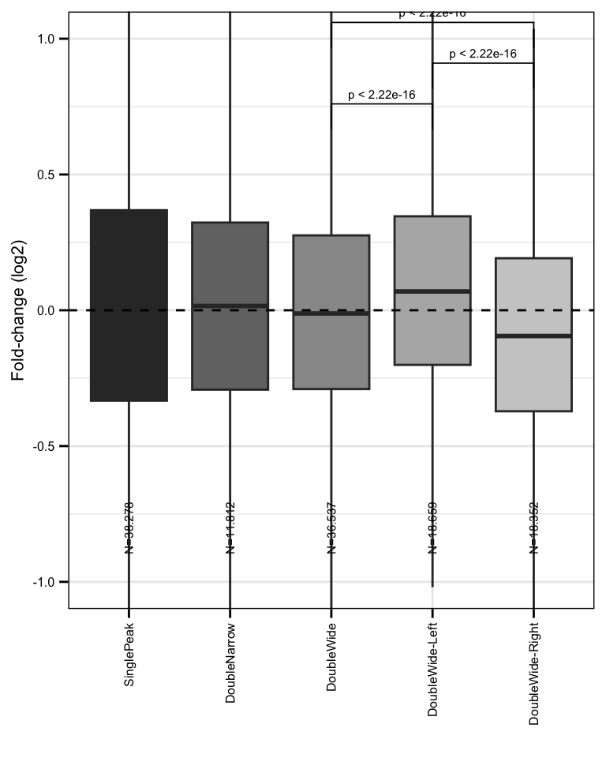

V2

```r
p2 = ggplot(df, aes(x = peakType, y = lfc, fill = peakType)) +
    geom_boxplot(outlier.colour = NA) +
    theme_pub() +
    scale_fill_grey() +
    theme(legend.position = "none") +
    geom_hline(yintercept = 0, linetype = "dashed") +
    labs(x = "", y = "Fold-change (log2)") +
    theme(axis.text.x = element_text(angle = 90, vjust = 0.5, hjust=1)) +
    coord_cartesian(ylim = c(-1,1)) +
    stat_compare_means(comparisons = compList, label = c("p.format"), method = "wilcox.test", label.y = c(0.45,0.6,0.3), tip.length = 0.01, size = 2) +
    geom_text(data = d, aes(x = peakType, y = -0.8, label = nNice), size = 2, angle = 90)

p2
```